# Mystery White Boy

Author

Ari Bendito

# Understanding Jeff Buckley

Jeffrey Scott Buckley (1966-1997) was an American singer, songwriter, artist rooted in the 1990s alternative rock. Although his career was cut short due to a tragic incident, he produced one of the most influential albums of the 90s that still continues to resonate with audiences decades later.

- 1994 - Grace

The only full studio album to be published during his lifetime, it expresses his artistic vision in its complete form. Many people consider the album as a masterpiece of alternative rock because of the beautiful lyrics, high vocals and fusion of jazz, folk and rock from the 1970s.

- 1997-98 - Death and Sketches for My Sweetheart The Drunk

Published in 1998, this is his first posthumous and unfinished album comprising songs he was making for his second album. It is titled ’Sketches” because he was dissatisfied with the initial studio sessions and was reworking them.

- 2016 - You and I

This is his second posthumous album, a compilation of recordings in 1993, made before recording Grace. It is a collection of raw, solo performances, the majority are cover songs functioning as a table of contents before he signed with Columbia Records.

## Popular Songs

[figure not shown]

“Lover, You Should’ve Come Over”

https://www.youtube.com/watch?v=HxfE6PJmGS8

“Everybody Here Wants You”

https://www.youtube.com/watch?v=hGzHCvkndnI&list=RDhGzHCvkndnI&start_radio=1

#### Importing Data

```r
options(repos = c(CRAN = "https://cloud.r-project.org/"))
# These are packages I need for the analysis
library(rmarkdown)
library(knitr)
library(ggplot2)
library(readr)
library(dplyr)
# Import data into df
Jeff_Buckley <- read_csv("Jeff Buckley.csv")
#View(Jeff_Buckley)

#Creating album
Albums <- Jeff_Buckley %>%
  filter(!album_name %in% c("You and I (Extended Edition)", "Grace", "Songs To No One"))
```

#### ANALYSIS

Plotting the difference in valence levels across albums:

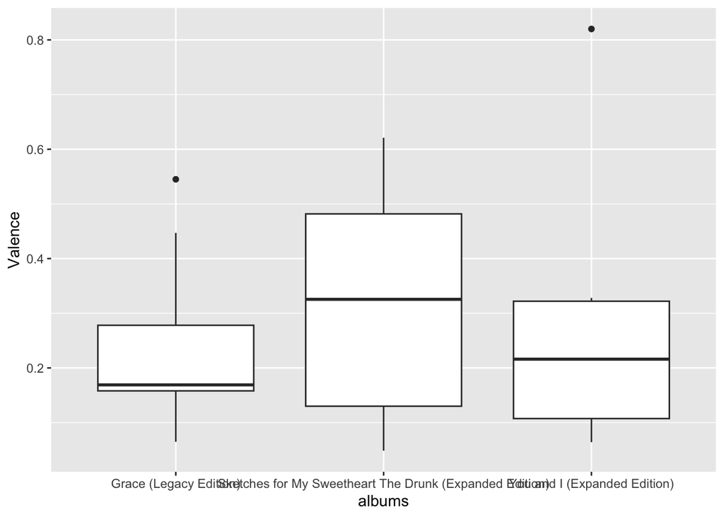

```r
# PLot a box plot

ggplot(Albums, aes(x=album_name, y= valence)) +
  geom_boxplot() +
  labs(x="albums", y= "Valence")
```

Plotting the difference in energy levels across albums:

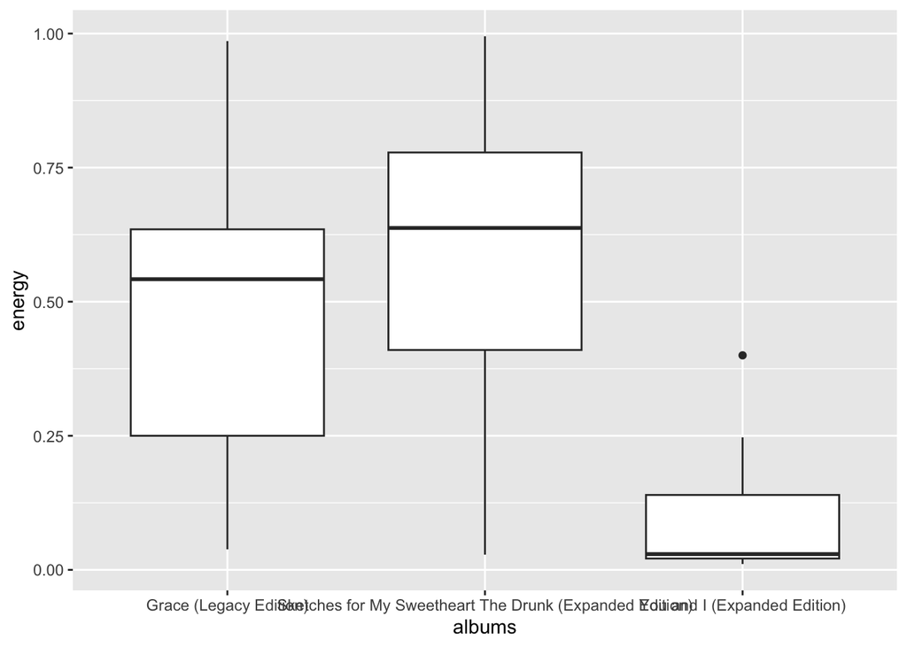

```r
# PLot a box plot
ggplot(Albums, aes(x=album_name, y= energy)) +
  geom_boxplot() +
  labs(x="albums", y= "energy")
```

How do valence and energy level change between the albums?

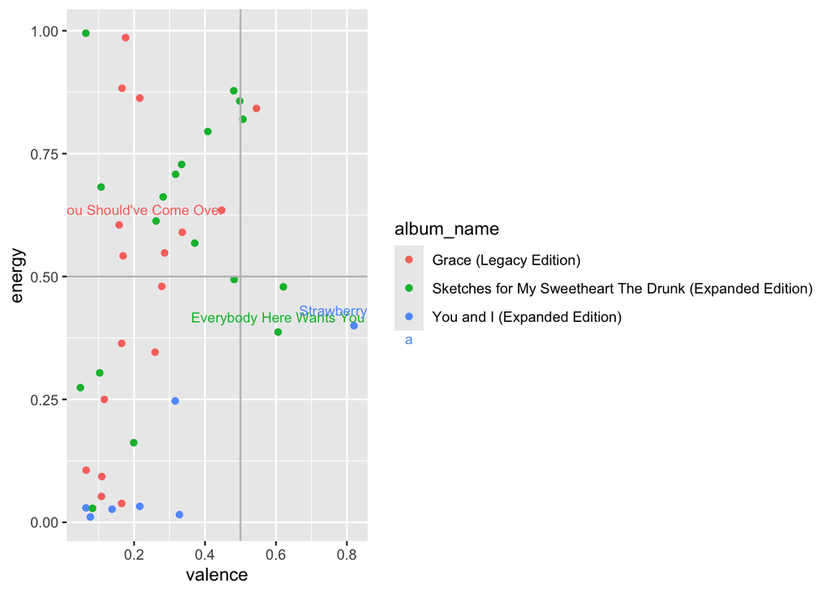

```r
#
subgroup <- Jeff_Buckley |> filter(track_name %in% c("Everybody Here Wants You", "Lover, You Should've Come Over", "Strawberry Street"))

ggplot(Albums, aes(x = valence, y = energy, color = album_name)) +
  geom_point() +
  geom_hline(yintercept = 0.5, color = "grey") +
  geom_vline(xintercept = 0.5, color = "grey") +
  geom_text(data = subgroup, aes(label = track_name),
             vjust = -1, size = 3)
```

Finding the 5 songs with the lowest valence

```r
#finding the minimum valence
Albums |>
  slice_min(valence, n=5) |>
  dplyr::select(track_name, album_name, album_release_year, valence) |>
  knitr::kable(digits = 2)
```

| track_name | album_name | album_release_year | valence |
| --- | --- | --- | --- |
| Morning Theft | Sketches for My Sweetheart The Drunk (Expanded Edition) | 1998 | 0.05 |
| Gunshot Glitter | Sketches for My Sweetheart The Drunk (Expanded Edition) | 1998 | 0.06 |
| Hallelujah | You and I (Expanded Edition) | 2016 | 0.06 |
| Lilac Wine | Grace (Legacy Edition) | 1994 | 0.06 |
| Mojo Pin | You and I (Expanded Edition) | 2016 | 0.08 |

Finding the 5 songs with the lowest energy

```r
#finding the minimum energy
Albums |>
  slice_min(energy, n=5) |>
  dplyr::select(track_name, album_name, album_release_year, energy) |>
  knitr::kable(digits = 2)
```

| track_name | album_name | album_release_year | energy |
| --- | --- | --- | --- |
| Mojo Pin | You and I (Expanded Edition) | 2016 | 0.01 |
| If You Knew | You and I (Expanded Edition) | 2016 | 0.02 |
| Satisfied Mind | You and I (Expanded Edition) | 2016 | 0.03 |
| You & I | Sketches for My Sweetheart The Drunk (Expanded Edition) | 1998 | 0.03 |
| Hallelujah | You and I (Expanded Edition) | 2016 | 0.03 |

Plotting the difference in danceability levels across albums:

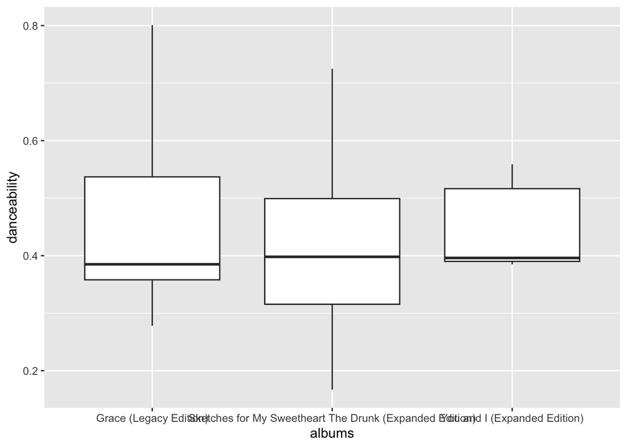

```r
# PLot a box plot
ggplot(Albums, aes(x=album_name, y= danceability)) +
  geom_boxplot() +
  labs(x="albums", y= "danceability")
```

Plotting the difference in speechiness levels across albums:

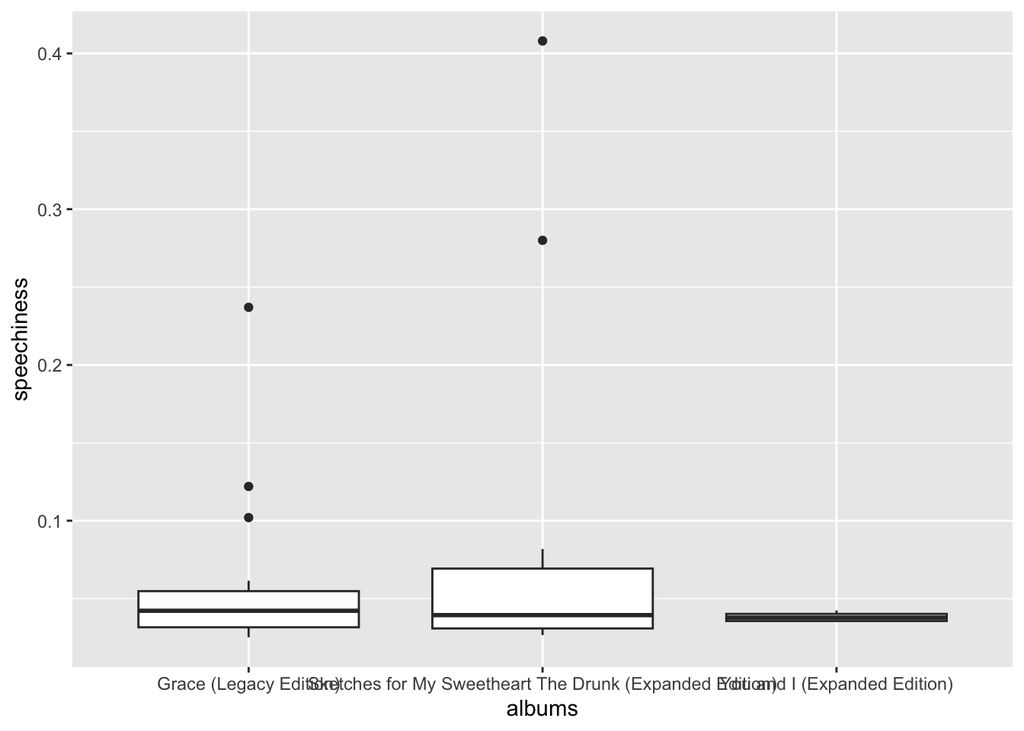

```r
# PLot a box plot
ggplot(Albums, aes(x=album_name, y= speechiness)) +
  geom_boxplot() +
  labs(x="albums", y= "speechiness")
```

Plotting the difference in liveness levels across albums:

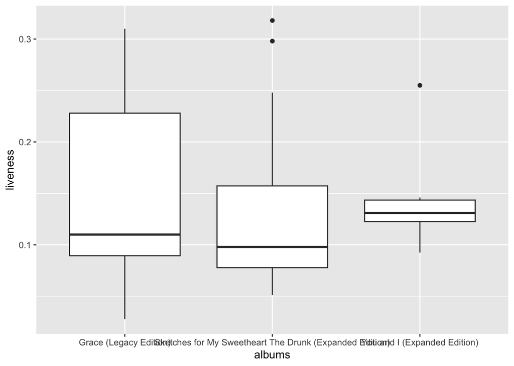

```r
# PLot a box plot
ggplot(Albums, aes(x=album_name, y= liveness)) +
  geom_boxplot() +
  labs(x="albums", y= "liveness")
```

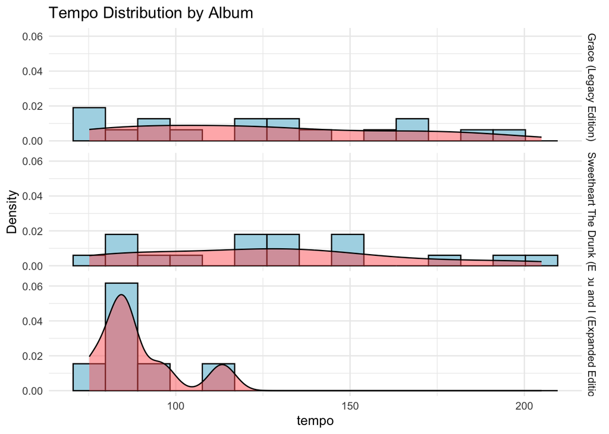

```r
ggplot(Albums, aes(x = tempo)) +
  geom_histogram(aes(y = after_stat(density)), fill="light blue", color = "black", bins= 15) +
  geom_density(fill = "#FF6666", alpha = 0.5) +
  facet_grid(album_name ~ .) +
  labs(title = "Tempo Distribution by Album",
       x = "tempo",
       y = "Density") +
  theme_minimal()
```

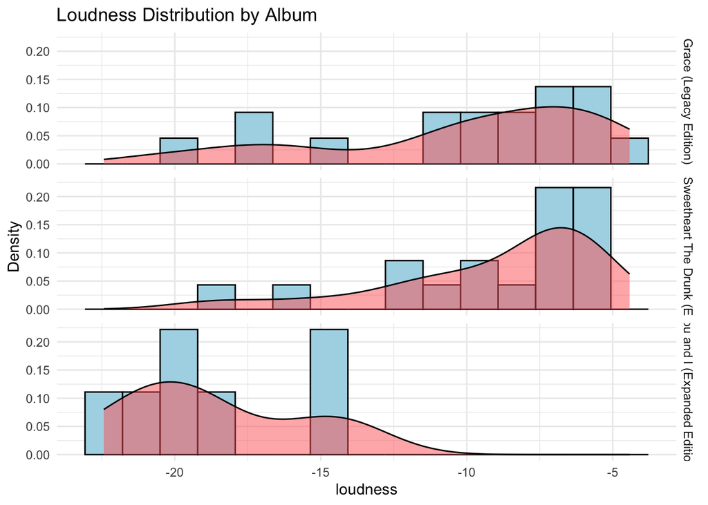

```r
ggplot(Albums, aes(x = loudness)) +
  geom_histogram(aes(y = after_stat(density)), fill="light blue", color = "black", bins= 15) +
  geom_density(fill = "#FF6666", alpha = 0.5) +
  facet_grid(album_name ~ .) +
  labs(title = "Loudness Distribution by Album",
       x = "loudness",
       y = "Density") +
  theme_minimal()
```

Loudness vs Energy

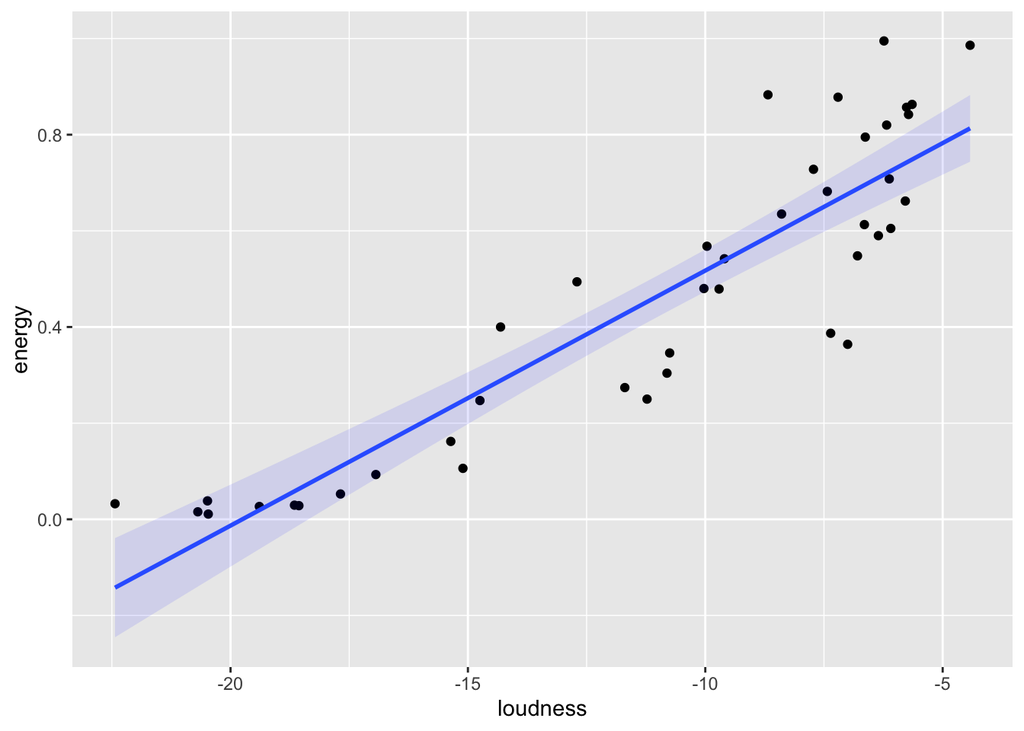

```r
ggplot(Albums, aes(x = loudness, y = energy)) +
  geom_point() +
  geom_smooth(method= "lm", alpha = 0.1, fill= "blue")
```

#### Conclusion:

Each album represents a different phase in Buckley’s artistic growth. Although he had a basic musical approach of valuing emotional intensity over plain positivity remained consistent. The tracks together tell the story of an artist whose voice continues to resonate decades after it went silent.